# Surface Water Quality Data

## Source of data:

### 1.For the below EDA, data is gathered from:https://data.baltimorecity.gov/datasets/surface-water-quality-data-1995-through-present/about

### Package Install and Import

### First, we will install and import necessary packages.

```python
#libraries to be installed
import pandas as pd # for creation of dataframe
import matplotlib.pyplot as plt # matplotlib graph (line,bar,hist,scatter)
import seaborn as sns # (distplot,vilion plot,boxplot,pair plot)
import matplotlib.pyplot as plt# A plotting library used for creating static, visualizations in Python.
import matplotlib.patches as mpatches
import numpy as np # library used for working with arrays.
import warnings #library used for handling warning messages.
warnings.filterwarnings('ignore')
```

## Loading the dataset

### Now we are ready to load the dataset. We will do this using the standard read_csv command from Pandas. Let's take a glimpse at how the data looks like.

```python
df = pd.read_csv("Surface_Water_Quality_Data_1995_through_December_2022.csv", encoding='iso-8859-1',low_memory=False)
```

```python
df
```

|  | OBJECTID | Station | GPS Coordinate North | GPS Coordinate West | Parameter | Lab | Result | Unit | datetime |
| --- | --- | --- | --- | --- | --- | --- | --- | --- | --- |
| 0 | 1 | HAMILTON AVE. | 39.33673 | -76.53967 | Copper_Total | Martel | 10 | ug/L | 4/3/1995 13:30 |
| 1 | 2 | HAMILTON AVE. | 39.33673 | -76.53967 | Fecal Coliform | Martel | 2400 | MPN/100ml | 4/3/1995 13:30 |
| 2 | 3 | HAMILTON AVE. | 39.33673 | -76.53967 | Lead_Total | Martel | 40 | ug/L | 4/3/1995 13:30 |
| 3 | 4 | HAMILTON AVE. | 39.33673 | -76.53967 | Oil & Grease | Martel | 2.8 | mg/L | 4/3/1995 13:30 |
| 4 | 5 | HAMILTON AVE. | 39.33673 | -76.53967 | Zinc_Total | Martel | 20 | ug/L | 4/3/1995 13:30 |
| ... | ... | ... | ... | ... | ... | ... | ... | ... | ... |
| 428101 | 428102 | STONY RUN @ GILMAN | 39.36086 | -76.62985 | Conductivity | WQM Field | 572 | umhos | 12/30/2022 3:54 PM |
| 428102 | 428103 | STONY RUN @ GILMAN | 39.36086 | -76.62985 | Dissolved Oxygen | WQM Field | 11.8 | mg/L | 12/30/2022 3:54 PM |
| 428103 | 428104 | STONY RUN @ GILMAN | 39.36086 | -76.62985 | Hach Ammonia-Nitrogen | WQM Field | 0 | mg/L | 12/30/2022 3:54 PM |
| 428104 | 428105 | STONY RUN @ GILMAN | 39.36086 | -76.62985 | pH | WQM Field | 7.42 | pH units | 12/30/2022 3:54 PM |
| 428105 | 428106 | STONY RUN @ GILMAN | 39.36086 | -76.62985 | Water Temperature | WQM Field | 8.9 | degrees Celsius | 12/30/2022 3:54 PM |

428106 rows × 9 columns

### After a Quick glimpse at the dataset, it looks like a typical quality of surface water from various locations in the USA.

# Data Preparation and Cleaning

### Dropping all null values as they have no importance in my analysis

```python
df = df.dropna()
```

```python
df.info()# to get the information of the datatype
```

```
<class 'pandas.core.frame.DataFrame'>
RangeIndex: 428106 entries, 0 to 428105
Data columns (total 9 columns):
 #   Column                Non-Null Count   Dtype
---  ------                --------------   -----
 0   OBJECTID              428106 non-null  int64
 1   Station               428106 non-null  object
 2   GPS Coordinate North  428106 non-null  float64
 3   GPS Coordinate West   428106 non-null  object
 4   Parameter             428106 non-null  object
 5   Lab                   428106 non-null  object
 6   Result                428106 non-null  object
 7   Unit                  428106 non-null  object
 8   datetime              428106 non-null  object
dtypes: float64(1), int64(1), object(7)
memory usage: 29.4+ MB
```

```python
# converted the data type , as few columns are having object data type instead of string.
df = df.convert_dtypes()
```

### 'convert_dtypes()' function is used to convert the columns to their appropriate data types.

```python
df.info()
```

```
<class 'pandas.core.frame.DataFrame'>
RangeIndex: 428106 entries, 0 to 428105
Data columns (total 9 columns):
 #   Column                Non-Null Count   Dtype
---  ------                --------------   -----
 0   OBJECTID              428106 non-null  Int64
 1   Station               428106 non-null  string
 2   GPS Coordinate North  428106 non-null  Float64
 3   GPS Coordinate West   428106 non-null  string
 4   Parameter             428106 non-null  string
 5   Lab                   428106 non-null  string
 6   Result                428106 non-null  string
 7   Unit                  428106 non-null  string
 8   datetime              428106 non-null  string
dtypes: Float64(1), Int64(1), string(7)
memory usage: 30.2 MB
```

```python
df.head()
```

|  | OBJECTID | Station | GPS Coordinate North | GPS Coordinate West | Parameter | Lab | Result | Unit | datetime |
| --- | --- | --- | --- | --- | --- | --- | --- | --- | --- |
| 0 | 1 | HAMILTON AVE. | 39.33673 | -76.53967 | Copper_Total | Martel | 10 | ug/L | 4/3/1995 13:30 |
| 1 | 2 | HAMILTON AVE. | 39.33673 | -76.53967 | Fecal Coliform | Martel | 2400 | MPN/100ml | 4/3/1995 13:30 |
| 2 | 3 | HAMILTON AVE. | 39.33673 | -76.53967 | Lead_Total | Martel | 40 | ug/L | 4/3/1995 13:30 |
| 3 | 4 | HAMILTON AVE. | 39.33673 | -76.53967 | Oil & Grease | Martel | 2.8 | mg/L | 4/3/1995 13:30 |
| 4 | 5 | HAMILTON AVE. | 39.33673 | -76.53967 | Zinc_Total | Martel | 20 | ug/L | 4/3/1995 13:30 |

```python
convert_dict = {'GPS Coordinate West': float,
                }

df = df.astype(convert_dict)
```

```python
df.info()# To get the infomation of the datatype
```

```
<class 'pandas.core.frame.DataFrame'>
RangeIndex: 428106 entries, 0 to 428105
Data columns (total 9 columns):
 #   Column                Non-Null Count   Dtype
---  ------                --------------   -----
 0   OBJECTID              428106 non-null  Int64
 1   Station               428106 non-null  string
 2   GPS Coordinate North  428106 non-null  Float64
 3   GPS Coordinate West   428106 non-null  float64
 4   Parameter             428106 non-null  string
 5   Lab                   428106 non-null  string
 6   Result                428106 non-null  string
 7   Unit                  428106 non-null  string
 8   datetime              428106 non-null  string
dtypes: Float64(1), Int64(1), float64(1), string(6)
memory usage: 30.2 MB
```

```python
df['datetime']=pd.to_datetime(df['datetime'])#This function is used to convert the 'datetime' column to the datetime data type.
```

```python
df.info()# to get the infomation of the datatype
```

```
<class 'pandas.core.frame.DataFrame'>
RangeIndex: 428106 entries, 0 to 428105
Data columns (total 9 columns):
 #   Column                Non-Null Count   Dtype
---  ------                --------------   -----
 0   OBJECTID              428106 non-null  Int64
 1   Station               428106 non-null  string
 2   GPS Coordinate North  428106 non-null  Float64
 3   GPS Coordinate West   428106 non-null  float64
 4   Parameter             428106 non-null  string
 5   Lab                   428106 non-null  string
 6   Result                428106 non-null  string
 7   Unit                  428106 non-null  string
 8   datetime              428106 non-null  datetime64[ns]
dtypes: Float64(1), Int64(1), datetime64[ns](1), float64(1), string(5)
memory usage: 30.2 MB
```

### There are 428106 entries and 9 columns to work with for EDA.

#### We use .describe to get the maximum, minimum and other statistical values in our dataframe.

```python
df.describe()# This function display the statistical summary of the DataFrame.
```

|  | OBJECTID | GPS Coordinate North | GPS Coordinate West |
| --- | --- | --- | --- |
| count | 428106.000000 | 428106.000000 | 428106.000000 |
| mean | 214053.500000 | 39.314712 | -76.617286 |
| std | 123583.701508 | 0.033675 | 0.053044 |
| min | 1.000000 | 39.239460 | -76.712220 |
| 25% | 107027.250000 | 39.283190 | -76.665590 |
| 50% | 214053.500000 | 39.314860 | -76.622608 |
| 75% | 321079.750000 | 39.339430 | -76.573970 |
| max | 428106.000000 | 39.371730 | -76.530450 |

```python
df.nunique()# The 'nunique()' function is used to count the number of unique values in each column.
```

```
OBJECTID                428106
Station                    162
GPS Coordinate North       157
GPS Coordinate West        158
Parameter                   49
Lab                          9
Result                   15191
Unit                         8
datetime                 51496
dtype: int64
```

# Sanity checks

## Sanity checks are performed on the following columns:

#### 1) is.na for whole df to check wheather null values are not present in df.

```python
# checking if there are any null values
df.isna().sum()
```

```
OBJECTID                0
Station                 0
GPS Coordinate North    0
GPS Coordinate West     0
Parameter               0
Lab                     0
Result                  0
Unit                    0
datetime                0
dtype: int64
```

```python
df.isnull().values.any() # checking if there are any null values in the entire dataframe df by returning a boolean value of True if there are any null values and False if there are none.
```

```
False
```

```python
df.drop_duplicates(inplace=True)# checking and drops duplicate rows from the DataFrame "df" and modifies it in place.
```

```python
df['Result'] = pd.to_numeric(df['Result'], errors='coerce') # this helps to convert 'Result' column to numeric data tyoe any of the non-numeric values will be replaced with NaN with  'errors' parameter set to 'coerce'.
```

```python
df["Result"] = df["Result"].astype(float)# changing  data type of the "Result" column in the DataFrame to float.
```

```python
df.info()# to get the information of datatype.
```

```
<class 'pandas.core.frame.DataFrame'>
Int64Index: 428106 entries, 0 to 428105
Data columns (total 9 columns):
 #   Column                Non-Null Count   Dtype
---  ------                --------------   -----
 0   OBJECTID              428106 non-null  Int64
 1   Station               428106 non-null  string
 2   GPS Coordinate North  428106 non-null  Float64
 3   GPS Coordinate West   428106 non-null  float64
 4   Parameter             428106 non-null  string
 5   Lab                   428106 non-null  string
 6   Result                397800 non-null  float64
 7   Unit                  428106 non-null  string
 8   datetime              428106 non-null  datetime64[ns]
dtypes: Float64(1), Int64(1), datetime64[ns](1), float64(2), string(4)
memory usage: 33.5 MB
```

1. Water Quality Trends
2. Quality of Water by Location
3. Creating a folium map of monitoring stations with average water quality results.
4. Creating a map with markers for each location in the dataset.
5. Monitoring the stations which have the highest and lowest water quality results
6. Water quality results vary by parameter
7. Water quality results vary by unit of measurement
8. Calculating average result by parameter
9. How many samples do we have for each value of the "Parameter" variable? Can we visualize this information using a histogram
10. Create a pivot table with parameters on the index and years on the columns
11. "Water Quality Trends at Different Stations over Time".

# Exploratory Data Analysis and Visualization

## 1. Water Quality Trends

#### Investigating the trends in water quality over time.

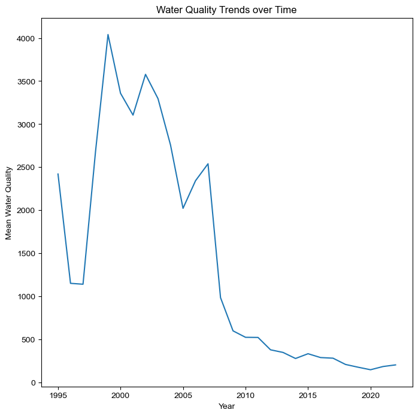

```python
plt.figure(figsize=(8, 8))# setting the size of the figure.

# here we are labeling x-axis as 'Year'.
plt.xlabel('Year')

# here we are labeling x-axis as 'Mean Water Quality'.
plt.ylabel('Mean Water Quality')

# here we are Setting the title of the plot as 'Water Quality Trends over Time'
plt.title('Water Quality Trends over Time')

# Here Grouping the water quality data by year and calculate the mean of the 'Result' column for each year
df_yearly = df.groupby(df['datetime'].dt.year).mean()

# Reseting the index to include the year as a column
df_yearly.reset_index(inplace=True)

# Creating a line plot of the water quality trends over time using seaborn
sns.lineplot(x='datetime', y='Result', data=df_yearly)

sns.set_style("darkgrid") # here we are setting the style of plot to "darkgrid".
```

## 2. Quality of Water by Location

```python
df_station = df.groupby(['Station']).mean()# here we are Grouping the water quality data by station and calculating the mean.
df_station.reset_index(inplace=True)# Resetting the index to include the station as a column.
```

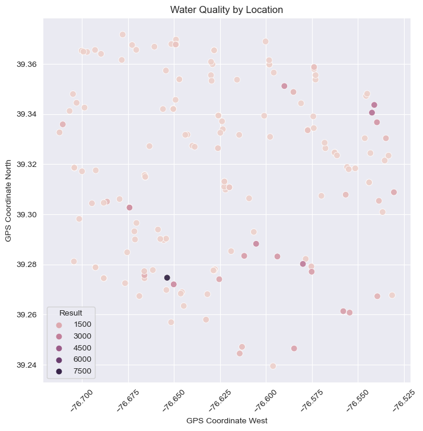

```python
# setting the size of the figure.
plt.figure(figsize=(8, 8))

# Here we are creating a scatter plot of the GPS coordinates of monitoring stations
sns.scatterplot(x='GPS Coordinate West', y='GPS Coordinate North', hue='Result',alpha = 0.9, s=60 ,data=df_station)

# here we are setting the style of plot to "darkgrid".
sns.set_style("darkgrid")

# here we are Setting the title of the plot as 'Water Quality by Location'.
plt.title('Water Quality by Location')

# here we are labeling x-axis as 'GPS Coordinate West'.
plt.xlabel('GPS Coordinate West')

# here we are labeling y-axis as 'GPS Coordinate North'.
plt.ylabel('GPS Coordinate North')

#x-axis ticks are set to be rotated 45 degrees.
plt.xticks(rotation=45)

plt.show()
```

From the above scatterplot, the hue represents the water quality result, where darker points represent higher water quality values and lighter points represent lower values. Since there are only a few data points with very high water quality values, those points are darker and the majority of the data points have lower water quality values, making them appear lighter in the plot. This suggests that overall, the water quality in the given locations may not be very high, but there are some exceptions with much better water quality values.

## 3. Creating a folium map of monitoring stations with average water quality results.

```python
import folium

# Creating a map centered on Baltimore, Maryland
map_baltimore = folium.Map(location=[39.2904, -76.6122], zoom_start=10)

# Creating a feature group for the monitoring stations
fg_stations = folium.FeatureGroup(name='Monitoring Stations')

# Adding a marker for each monitoring station
for index, row in df_station.iterrows():
    lat = row['GPS Coordinate North']
    lon = row['GPS Coordinate West']
    station_name = row['Station']
    avg_result = row['Result']
    popup_text = f'Station: {station_name}<br>Average Result: {avg_result:.2f}'
    fg_stations.add_child(folium.Marker(location=[lat, lon], popup=popup_text))

# Adding the feature group to the map
map_baltimore.add_child(fg_stations)

# Adding a layer control to toggle the feature groups
folium.LayerControl().add_to(map_baltimore)

# Displays the map
map_baltimore
```

Make this Notebook Trusted to load map: File -> Trust Notebook

[interactive chart not shown]

1. The markers on the folium map represent the monitoring stations and provide additional information when clicked. i.e, the marker displays the name of the station and the average water quality result recorded at that location.
2. This visualization allows the user to quickly see the locations of monitoring stations in Baltimore, Maryland and get an idea of the average water quality results at each station.

## 4. Creating a map with markers for each location in the dataset.

```python
df_location = df.groupby('Station').mean().reset_index()# here we are here we are Grouping the water quality data by station and calculating the mean then resets the index to include 'Station' as a column.
```

```python
import folium

# Setting the map coordinates to the center of the USA
map = folium.Map(location=[39.50, -98.35], zoom_start=4)

# Adding markers to the map for each location
for i in range(len(df_location)):
    folium.Marker(location=[df_location.iloc[i]['GPS Coordinate North'], df_location.iloc[i]['GPS Coordinate West']],
                  popup=df_location.iloc[i]['Station'] + ': ' + str(df_location.iloc[i]['Result']),
                  icon=None).add_to(map)

map # Displays the map
```

Make this Notebook Trusted to load map: File -> Trust Notebook

[interactive chart not shown]

From the above map with markers that represent the average water quality results for each monitoring station in the dataset. The location of each marker is determined by the latitude and longitude coordinates of the monitoring station. When a marker is clicked, a popup appears that displays the name of the monitoring station and its average water quality result

## 5. Monitoring the stations which have the highest and lowest water quality results?

[figure not shown]

```python
# Grouping the df by the Station column, then calculating the mean of the Result column for each group (station), and sorting the values in ascending order. The resulting dataframe is then filtered to drop any rows that contain missing values.
df_by_station = df.groupby('Station')['Result'].mean().sort_values().dropna().reset_index()

# creating a barplot using seaborn, where the x-axis represents the 'Result' and the y-axis represents the 'Station'.
sns.barplot(x='Result', y='Station', data=df_by_station.head(10))

# here we are Setting the title of the plot as 'Top 10 Stations with Highest Average Water Quality Results'.
plt.title('Top 10 Stations with Highest Average Water Quality Results')

# here we are labeling x-axis as 'Result'.
plt.xlabel('Result')

# here we are labeling y-axis as 'station'.
plt.ylabel('Station')# here we are labeling y-axis as 'station'.

plt.show()
```

[figure not shown]

```python
# creating a bar plot of the average water quality results for the 10 stations with the lowest average results.
sns.barplot(x='Result', y='Station', data=df_by_station.tail(10))

# here we are Setting the title of the plot as 'Top 10 Stations with Lowest Average Water Quality Results'.
plt.title('Top 10 Stations with Lowest Average Water Quality Results')

# here we are labeling x-axis as 'Result'.
plt.xlabel('Result')

# here we are labeling y-axis as 'station'.
plt.ylabel('Station')

plt.show()
```

This code groups the data by station and calculates the average water quality result for each station, then generates bar plots of the top 10 stations with the highest and lowest results.

## 6. Water quality results vary by parameter

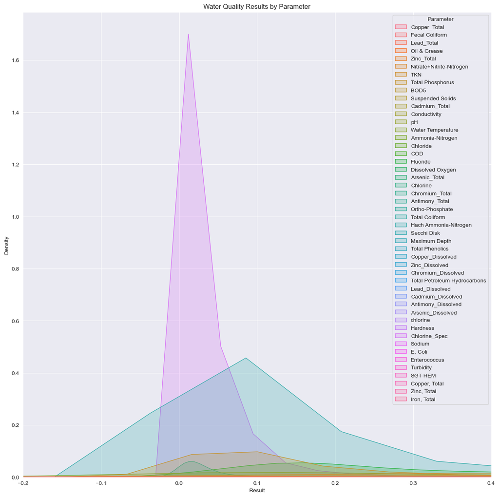

```python
# Setting the size of the figure to 15 x 15 inches
plt.figure(figsize=(15, 15))

# Setting the style of the plot to 'darkgrid'
sns.set_style("darkgrid")

# Creating a KDE plot of water quality results by parameter, with shading enabled
sns.kdeplot(x='Result', hue='Parameter', data=df.dropna(), shade=True)

# Setting the x-axis limits to focus on the majority of data
plt.xlim(left=-0.2, right=0.40)

# here we are Setting the title of the plot to 'Water Quality Results by Parameter'
plt.title('Water Quality Results by Parameter')

# here we are labeling x-axis as 'Result'.
plt.xlabel('Result')

# here we are labeling x-axis as 'Density'.
plt.ylabel('Density')

# Displaying the plot
plt.show()
```

## 7. Water quality results vary by unit of measurement

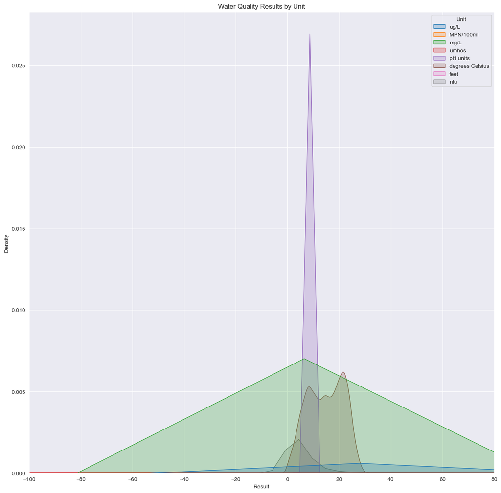

```python
# Setting the figure size to 15x15
plt.figure(figsize=(15, 15))

# Setting the style of the plot to "darkgrid"
sns.set_style("darkgrid")

# Creating a kernel density plot of the "Result" column, with each unit represented by a different hue and shaded areas
sns.kdeplot(df["Result"],hue = df['Unit'], shade = True)

# setting x-axis limits to focus on majority of data.
plt.xlim(left=-100, right=80)

# here we are Setting the title of the plot to 'Water Quality Results by Unit'.
plt.title('Water Quality Results by Unit')

# Setting the x-label as 'Result'
plt.xlabel('Result')

# Setting the y-label as 'Density'
plt.ylabel('Density')

plt.show()
```

The graph represents the distribution of water quality results by unit, with the kernel density plot showing the density of results. The different colors indicate different units of measurement for the water quality parameters. The x-axis represents the result values, and the y-axis represents the density of results. The plot helps to visualize the range and distribution of water quality results by unit.

```python
# Average value of the "Result" variable
average_result = df['Result'].mean()
print("Average Result Value:", average_result)

# Maximum value of the "Result" variable
max_result = df['Result'].max()
print("Maximum Result Value:", max_result)

# Minimum value of the "Result" variable
min_result = df['Result'].min()
print("Minimum Result Value:", min_result)
```

```
Average Result Value: 1131.1808754266385
Maximum Result Value: 1600000.0
Minimum Result Value: -0.71
```

## 8.Calculating average result by parameter

```python
# Grouping the data by "Parameter" and calculate the average "Result" value for each group
result_by_parameter = df.groupby('Parameter')['Result'].mean().sort_values().dropna()
print(result_by_parameter)
```

```
Parameter
Ortho-Phosphate                     0.030909
Chlorine_Spec                       0.033280
chlorine                            0.050000
Total Phosphorus                    0.132913
Hach Ammonia-Nitrogen               0.166882
Chlorine                            0.203883
Cadmium_Dissolved                   0.292500
Ammonia-Nitrogen                    0.295134
Fluoride                            0.331282
SGT-HEM                             0.950000
Cadmium_Total                       1.007674
TKN                                 1.069010
Lead_Dissolved                      1.259129
Arsenic_Dissolved                   1.356930
Nitrate+Nitrite-Nitrogen            1.579248
Arsenic_Total                       2.465877
Antimony_Dissolved                  2.957000
Antimony_Total                      3.206453
Total Petroleum Hydrocarbons        3.222353
Secchi Disk                         3.455977
Lead_Total                          3.971285
Copper_Dissolved                    5.230875
Copper, Total                       5.600000
BOD5                                5.731194
Oil & Grease                        5.930216
pH                                  7.775974
Turbidity                           7.842646
Suspended Solids                    8.727675
Maximum Depth                       9.000000
Copper_Total                        9.306457
Dissolved Oxygen                   10.181689
Zinc, Total                        14.450000
Water Temperature                  14.742247
Total Phenolics                    24.250000
Zinc_Dissolved                     25.797671
Zinc_Total                         37.517804
Chromium_Total                     39.114134
COD                                48.480121
Chromium_Dissolved                 51.141687
Sodium                             80.315740
Hardness                          256.370550
Iron, Total                       488.000000
Chloride                          569.527153
Conductivity                     1562.488954
Enterococcus                     3462.769181
E. Coli                          3527.869068
Fecal Coliform                  22990.363157
Total Coliform                  64740.806895
Name: Result, dtype: float64
```

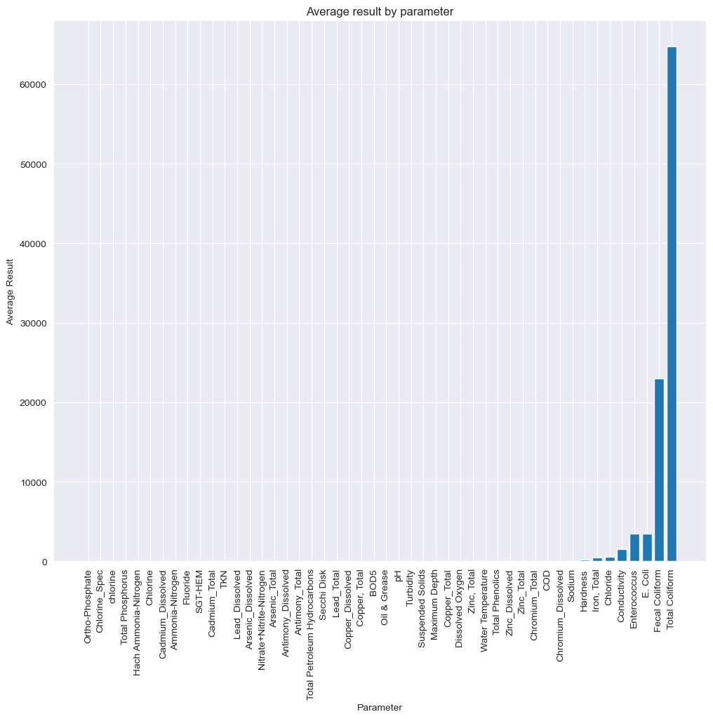

```python
# Setting the figure size to 12x10
plt.figure(figsize=(12,10))

# Visualizing the relationship between "Parameter" and "Result" using a bar chart
plt.bar(result_by_parameter.index, result_by_parameter.values)

# Setting the x-label as 'Parameter'
plt.xlabel('Parameter')

# Setting the y-label as 'Average Result'.
plt.ylabel('Average Result')

# here we are Setting the title of the plot to 'Average result by parameter'.
plt.title('Average result by parameter')

#x-axis ticks are set to be rotated 90 degrees.
plt.xticks(rotation=90)

plt.show()
```

The graph is useful for identifying which parameters have higher or lower average result values and can be used to prioritize water quality testing and monitoring efforts.

## 9. How many samples do we have for each value of the "Parameter" variable? Can we visualize this information using a histogram?

```python
# Count the number of samples for each value of the "Parameter" variable
parameter_counts = df['Parameter'].value_counts().sort_values()
print(parameter_counts)
```

```
chlorine                            1
Maximum Depth                       2
Iron, Total                         5
Zinc, Total                         8
Lead, Total                         8
Copper, Total                      19
Secchi Disk                        94
SGT-HEM                           128
Total Petroleum Hydrocarbons      130
Total Phenolics                   199
Oil & Grease                      344
Arsenic_Dissolved                 454
Antimony_Dissolved                457
Cadmium_Dissolved                 616
Chromium_Dissolved                739
Sodium                            885
Ortho-Phosphate                  1304
Lead_Dissolved                   1829
Zinc_Dissolved                   1850
Copper_Dissolved                 1853
Antimony_Total                   2706
Arsenic_Total                    2724
Enterococcus                     2818
Cadmium_Total                    3127
Chromium_Total                   3671
Total Coliform                   3765
E. Coli                          4107
BOD5                             4299
Fecal Coliform                   4438
Hardness                         4506
Ammonia-Nitrogen                 4625
Chlorine                         4723
Zinc_Total                       6987
Lead_Total                       6993
Copper_Total                     6994
Fluoride                         8763
Chloride                         8841
COD                              9054
Total Phosphorus                 9898
TKN                              9916
Nitrate+Nitrite-Nitrogen         9918
Turbidity                       10989
Suspended Solids                11316
Dissolved Oxygen                37927
Chlorine_Spec                   42656
pH                              44094
Water Temperature               46517
Conductivity                    50369
Hach Ammonia-Nitrogen           50440
Name: Parameter, dtype: Int64
```

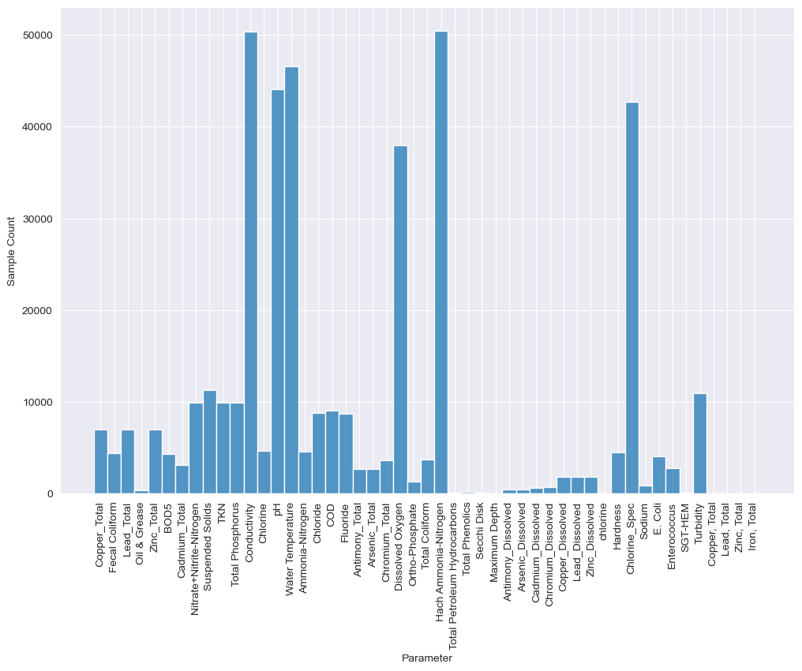

```python
# Setting the figure size 12x8
plt.figure(figsize=(12, 8))

# Creating a histogram of the counts of each unique value of the 'Parameter' column in the df DataFrame.
sns.histplot(data=df, x='Parameter', bins=len(parameter_counts))

#x-axis ticks are set to be rotated 90 degrees.
plt.xticks(rotation=90)

# Setting the x-label as 'Parameter'
plt.xlabel('Parameter')

# Setting the y-label as 'Sample Count'.
plt.ylabel('Sample Count')

plt.show()
```

## 10.Create a pivot table with parameters on the index and years on the columns

```python
# creating a pivot table with the index as 'Parameter', columns as years extracted from the 'datetime' column, and values as the mean 'Result' for each year and parameter combination.
parameter_pivot = pd.pivot_table(df, index='Parameter', columns=df['datetime'].dt.year, values='Result')
```

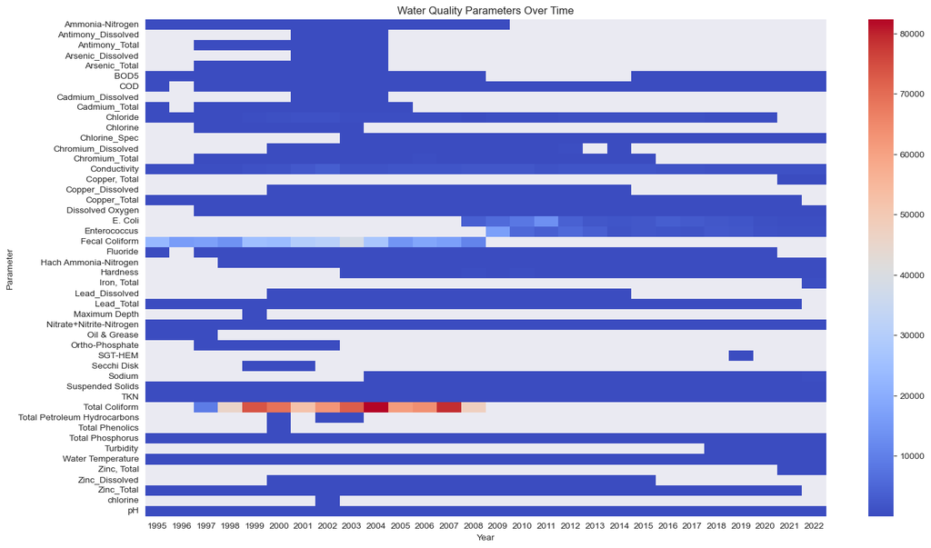

```python
# plotting  the pivot table as a heatmap

# Setting the figure size to 17x10
plt.figure(figsize=(17,10))

#creating a heatmap using seaborn with the pivot table parameter_pivot as input and setting the color scheme to 'coolwarm'.
sns.heatmap(parameter_pivot, cmap='coolwarm')

# here we are Setting the title of the plot to 'Water Quality Parameters Over Time'.
plt.title('Water Quality Parameters Over Time')

# Setting the x-label as 'Year'
plt.xlabel('Year')

# Setting the y-label as 'Parameter'.
plt.ylabel('Parameter')

plt.show()
```

## 11. Water Quality Trends at Different Stations over Time

```python
# selecting data from 2000 to 2022
df_selected = df[(df['datetime'] >= '2000-01-01') & (df['datetime'] <= '2022-12-31')]

# calculating average result for each station by year
df_by_station_year = df_selected.groupby(['Station', df_selected['datetime'].dt.year])['Result'].mean().reset_index()

# creating a pivot table to make year as column and station as row
df_pivot = df_by_station_year.pivot(index='Station', columns='datetime', values='Result')

# calculating percent change in result from 2000 to 2022 for each station
df_pivot['change'] = (df_pivot[2022] - df_pivot[2000]) / df_pivot[2000] * 100

# sorting stations by change in result
df_change = df_pivot.sort_values(by='change', ascending=False)

# selecting top 10 stations with highest improvement in water quality
df_top_improve = df_change.nlargest(10, 'change')

# selecting top 10 stations with highest deterioration in water quality
df_top_deteriorate = df_change.nsmallest(10, 'change')
```

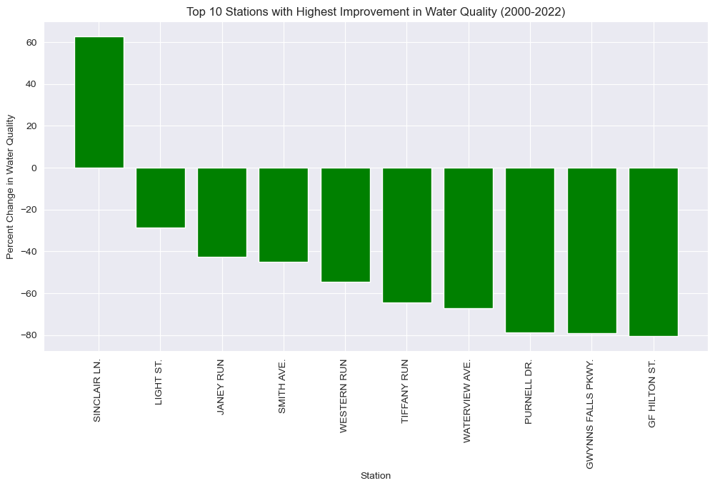

```python
# plotting changes in water quality for top 10 stations with highest improvement

# Setting the figure size 12x6
plt.figure(figsize=(12, 6))

# creating a bar chart of the df_top_improve with bars colored in green.
plt.bar(df_top_improve.index, df_top_improve['change'], color='g')

#x-axis ticks are set to be rotated 90 degrees.
plt.xticks(rotation=90)

# Setting the x-label as 'Station'
plt.xlabel('Station')

# Setting the y-label as 'Percent Change in Water Quality'.
plt.ylabel('Percent Change in Water Quality')

# here we are Setting the title of the plot to 'Top 10 Stations with Highest Improvement in Water Quality (2000-2022)'.
plt.title('Top 10 Stations with Highest Improvement in Water Quality (2000-2022)')

plt.show()
```

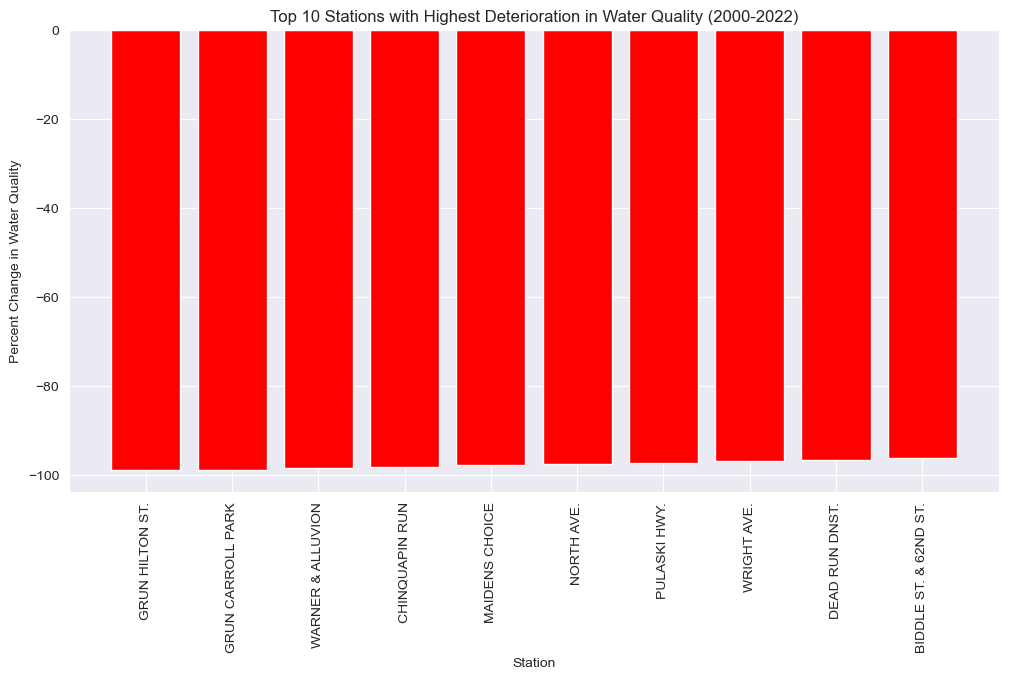

```python
# plotting changes in water quality for top 10 stations with highest deterioration


# Setting the figure size 12x6
plt.figure(figsize=(12, 6))

# creating a bar chart of the df_top_deteriorate with bars colored in red.
plt.bar(df_top_deteriorate.index, df_top_deteriorate['change'], color='r')

#x-axis ticks are set to be rotated 90 degrees.
plt.xticks(rotation=90)

# Setting the x-label as 'Station'
plt.xlabel('Station')

# Setting the y-label as 'Percent Change in Water Quality'.
plt.ylabel('Percent Change in Water Quality')

# here we are Setting the title of the plot to 'Top 10 Stations with Highest Deterioration in Water Quality (2000-2022)'.
plt.title('Top 10 Stations with Highest Deterioration in Water Quality (2000-2022)')

plt.show()
```

First, we select data from 2000 to 2022 using boolean indexing. Next, we group the data by station and year, and calculate the average result. We pivot the resulting table to make year as column and station as row. We calculate the percent change in result from 2000 to 2022 for each station. We sort the stations by change in result, and select the top 10 stations with highest improvement and deterioration in water quality. Finally, we plot the change in water quality for the top 10 stations with highest improvement and deterioration separately.

## Result From Above Analysis

The main goal of this project is to analyse the Surface Water Quality Data.

In this project we used various charts , sorting, aggregation and many other python concepts to get the in depth analysis of this data set, we have asked done some analysis and summarized respectively.

## Inferences and Conclusion

This dataset helps us understand a lot of things about the Surface Water Quality . After doing just some of the questions above I realized the importance of data There is variation in water quality across different monitoring stations in Baltimore. Some monitoring stations consistently show higher water quality results, indicating better water quality in those areas. Certain parameters have higher average water quality results compared to others, indicating their significance in assessing water quality. The sample counts for different parameters vary, with some parameters having a higher frequency of occurrence in the dataset compared to others.

## References and Future Work

## References :

1. Used this for plotting diferent types of graphs https://seaborn.pydata.org/#
2. For knowing more about pandas and it's functions in deatil - https://pandas.pydata.org
3. For more ideas on Matplotlib and it's library- https://matplotlib.org

## Future Work:

Building predictive models to forecast water quality levels based on various factors such as location, weather conditions, and other relevant variables. This can help in proactive management and decision-making related to water quality control and interventions.